# U.S. Election Prediction Modeling

Zach Jordan

# **Abstract**

In the past few U.S. elections, the polling of presidential candidates has been wildly off and a poor predictor of actual results. This analysis seeks to find an alternative solution to current polling standards by looking at data from the entirety of the term leading up to the election. We set a hypothesis that elections are a predictable process and that Americans vote not based upon the candidate, but rather what the current political party does in office. We will investigate this through a series of logistic regression functions, measuring the impact that each variable has on the determination of the next president’s political affiliation. Although the results were inconclusive, it creates reason for this study to be investigated further and more in-depth.

# **Introduction**

This data set is comprised of data from “The American Presidency Project” and includes a variety of statistics from the previous 12 U.S. presidential terms (1972 - 2016). I did not go back any further in the election process because previous elections had a relevant impact of a third-party candidate and this analysis focuses on the two major parties in the United States, Democratic and Republican. Within this data set we also have 3 impeachment proceedings, which do not occur often outside the 40 year time span. To begin we will first load in our data and format it to better suit our needs.

# **Loading data**

```r
#install.packages("tidyverse", dependencies = TRUE )
library(tidyverse)
elections <- read.csv("/Users/z_jordan/Desktop/Data for Project - Election Data.csv", na.strings=c(""))

elections$Year <- factor(elections$Year)
elections$Previous_Voter_Turnout <- parse_number(as.character(elections$Previous_Voter_Turnout))
elections$Current_President_Party <- factor(elections$Current_President_Party)
elections$Change_In_Power <- factor(elections$Change_In_Power)
elections$Impeachment_Presence <- factor(elections$Impeachment_Presence)
elections$Winner <- factor(elections$Winner)
elections$National_Winner <- factor(elections$National_Winner)
elections$State <- factor(elections$State)
```

## Variables

Here we are given the variables involved. These are all based upon statistics that lead up to the next election, as denoted by the year.

```r
colnames(elections)
```

```
##  [1] "Year"                              "State"
##  [3] "Total_Electors"                    "Current_President_Party"
##  [5] "President_Initial_Approval"        "President_Initial_Disapproval"
##  [7] "President_Mid_Approval"            "President_Mid_Disapproval"
##  [9] "President_Last_Approval"           "President_Last_Disapproval"
## [11] "President_Party_Mid_Change_House"  "President_Party_Mid_Change_Senate"
## [13] "President_News_Conference"         "President_Ex_Orders"
## [15] "Previous_Popular_Margin"           "Previous_Electoral_Margin"
## [17] "Previous_Voter_Turnout"            "Change_In_Power"
## [19] "Impeachment_Presence"              "Winner"
## [21] "National_Winner"
```

## Data

The data is composed of the above variables with each state having 13 entries, each state entry having a unique year. The lead up election data is shared by every state with the same year.

```r
print(as_tibble(elections))
```

```
## # A tibble: 663 x 21
##    Year  State Total_Electors Current_Preside… President_Initi… President_Initi…
##    <fct> <fct>          <int> <fct>                       <int>            <int>
##  1 1972  Alab…              9 Republican                     59                5
##  2 1976  Alab…              9 Republican                     71                3
##  3 1980  Alab…              9 Democratic                     66                8
##  4 1984  Alab…              9 Republican                     51               13
##  5 1988  Alab…              9 Republican                     64               28
##  6 1992  Alab…              9 Republican                     51                6
##  7 1996  Alab…              9 Democratic                     58               20
##  8 2000  Alab…              9 Democratic                     60               31
##  9 2004  Alab…              9 Republican                     57               25
## 10 2008  Alab…              9 Republican                     57               40
## # … with 653 more rows, and 15 more variables: President_Mid_Approval <int>,
## #   President_Mid_Disapproval <int>, President_Last_Approval <int>,
## #   President_Last_Disapproval <int>, President_Party_Mid_Change_House <int>,
## #   President_Party_Mid_Change_Senate <int>, President_News_Conference <int>,
## #   President_Ex_Orders <int>, Previous_Popular_Margin <dbl>,
## #   Previous_Electoral_Margin <dbl>, Previous_Voter_Turnout <dbl>,
## #   Change_In_Power <fct>, Impeachment_Presence <fct>, Winner <fct>,
## #   National_Winner <fct>
```

## Summary

```r
summary(elections)
```

```
##       Year            State     Total_Electors  Current_President_Party
##  1972   : 51   Alabama   : 13   Min.   : 3.00   Democratic:255
##  1976   : 51   Alaska    : 13   1st Qu.: 4.00   Republican:408
##  1980   : 51   Arizona   : 13   Median : 8.00
##  1984   : 51   Arkansas  : 13   Mean   :10.55
##  1988   : 51   California: 13   3rd Qu.:12.00
##  1992   : 51   Colorado  : 13   Max.   :55.00
##  (Other):357   (Other)   :585
##  President_Initial_Approval President_Initial_Disapproval
##  Min.   :45.00              Min.   : 3.00
##  1st Qu.:52.00              1st Qu.: 8.00
##  Median :58.00              Median :20.00
##  Mean   :58.31              Mean   :21.69
##  3rd Qu.:64.00              3rd Qu.:31.00
##  Max.   :71.00              Max.   :47.00
##
##  President_Mid_Approval President_Mid_Disapproval President_Last_Approval
##  Min.   :38.00          Min.   :27                Min.   :25.00
##  1st Qu.:43.00          1st Qu.:30                1st Qu.:44.00
##  Median :47.00          Median :36                Median :51.00
##  Mean   :50.62          Mean   :40                Mean   :46.92
##  3rd Qu.:58.00          3rd Qu.:48                3rd Qu.:54.00
##  Max.   :66.00          Max.   :56                Max.   :58.00
##
##  President_Last_Disapproval President_Party_Mid_Change_House
##  Min.   :33.00              Min.   :-63.00
##  1st Qu.:38.00              1st Qu.:-30.00
##  Median :45.00              Median :-15.00
##  Mean   :45.54              Mean   :-21.46
##  3rd Qu.:52.00              3rd Qu.: -8.00
##  Max.   :70.00              Max.   :  8.00
##
##  President_Party_Mid_Change_Senate President_News_Conference
##  Min.   :-9                        Min.   : 6
##  1st Qu.:-6                        1st Qu.:18
##  Median :-3                        Median :34
##  Mean   :-3                        Mean   :33
##  3rd Qu.: 1                        3rd Qu.:41
##  Max.   : 2                        Max.   :89
##
```

[output cut: 9 more lines]

```
##  Min.   : 73026831      No :561         No :510              Democrat  :230
##  1st Qu.: 86496851      Yes:102         Yes:153              Republican:382
##  Median : 96389818                                           NA's      : 51
##  Mean   :102250887
##  3rd Qu.:122349480
##  Max.   :136787187
##
##    National_Winner
##  Democrat  :255
##  Republican:357
##  NA's      : 51
##
##
##
##
```

# **EDA**

Now that we have our data loaded in properly, we can begin our exploratory data analysis and see what exactly we’re working with.

## Single Variable Graphs

### Voter Turnout

From this graph we are able to see the total number of voters in the election prior to each year. The number is increasing as time goes on, which could mean either the population of voters is increasing or the political activism is becoming stronger. We also see a spike from the 1992 election, which could be due to a strong candidate or because the U.S. doesn’t like the current president/presidential party.

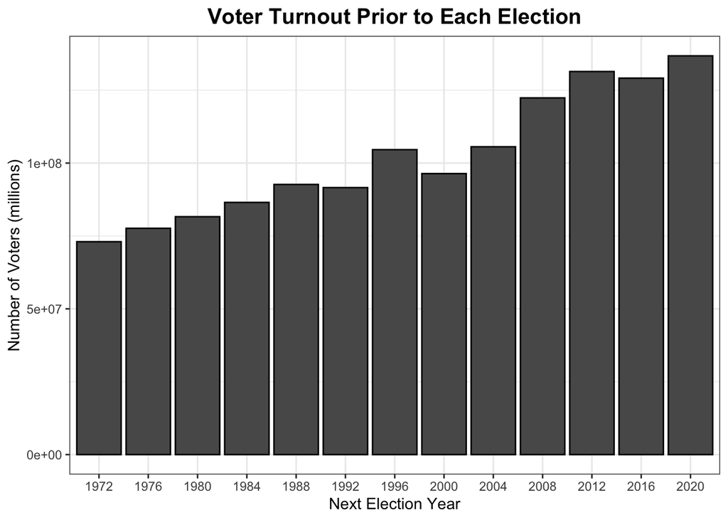

```r
voter_turnout <- elections %>%
    filter(State == "Alabama") %>%
    ggplot(aes(Year, Previous_Voter_Turnout))+
    geom_bar(stat = "identity", color = "black") +
    theme_bw() +
    labs(x="Next Election Year", y="Number of Voters (millions)", title="Voter Turnout Prior to Each Election") +
    theme(
        plot.title = element_text(hjust = 0.5, face = "bold", size = 15),
        axis.title = element_text(size = 11),
        )

voter_turnout
```

### Electoral Split

This shows the difference in electoral votes between the two parties in an election year. We see that the two parties are slowly getting closer together, which could be a reason why the polling is so off.

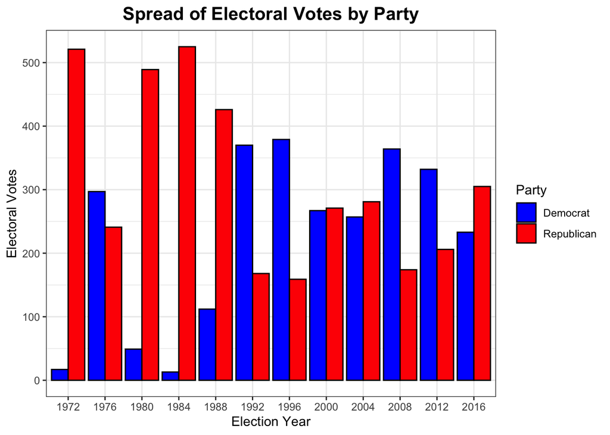

```r
electoral_votes <- elections %>%
    filter(Year != "2020") %>%
    group_by(Year, Winner) %>%
    summarise(Total_Electors = sum(Total_Electors)) %>%
    ungroup() %>%
    ggplot(aes(x=Year, y=Total_Electors, fill=Winner)) +
    geom_bar(stat='identity', position='dodge', color ="black") +
    scale_fill_manual(values = c("blue", "red"))  +
    theme_bw() +
    labs(x="Election Year", y="Electoral Votes", title="Spread of Electoral Votes by Party", fill = "Party") +
    theme(
        plot.title = element_text(hjust = 0.5, face = "bold", size = 15),
        axis.title = element_text(size = 11),
        )
electoral_votes
```

### Executive Orders

Here we have the break down of executive orders leading up to the listed election and what party they occurred from. Over all, it stay pretty steady, but the was a peak from 1976-1980 and the parties changed.

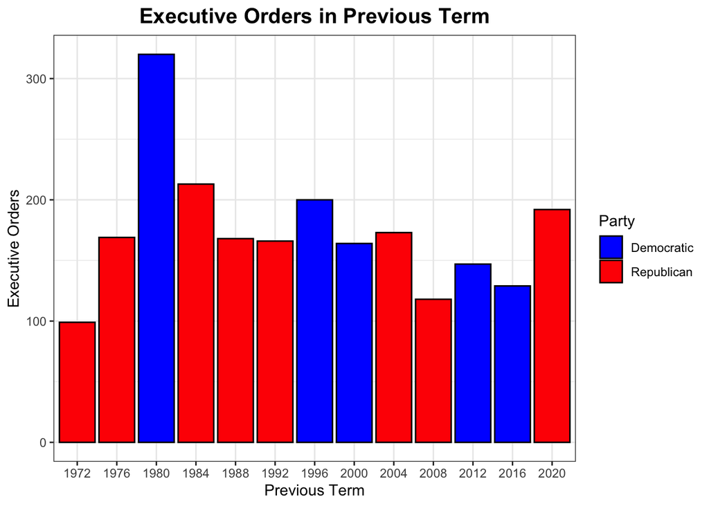

```r
party_executive_orders <- elections %>%
    filter(State == "Alabama") %>%
    ggplot(aes(Year, President_Ex_Orders, fill = Current_President_Party))+
    geom_bar(stat = "identity", color = "black") +
    scale_fill_manual(values = c("blue", "red"))  +
    theme_bw() +
    labs(x="Previous Term", y="Executive Orders", title="Executive Orders in Previous Term", fill = "Party") +
    theme(
        plot.title = element_text(hjust = 0.5, face = "bold", size = 15),
        axis.title = element_text(size = 11),
        )


party_executive_orders
```

## State Voting History

### States Matching Winning Party

This graphic shows the number of times states votes matched the president elect’s party. We see near the top most of our swing states, which is no surprising because they usually decide and election so it would make sense that the match the outcome. We also see that Ohio has been on the side of the president elect’s party for the previous 12 elections.

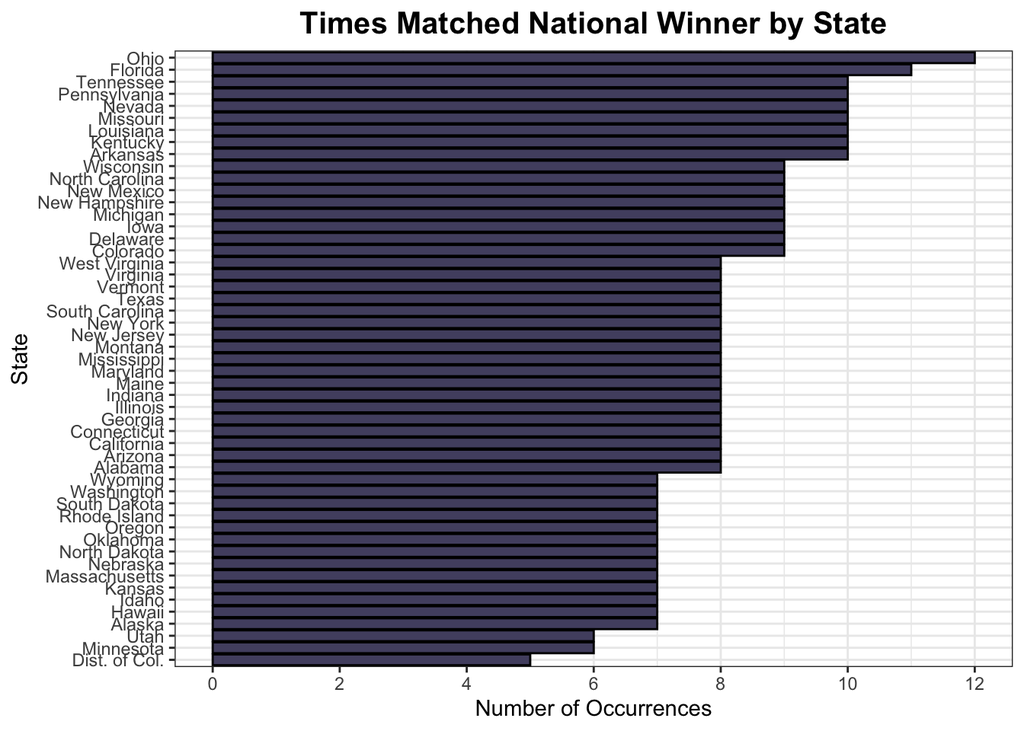

```r
correct_state_voting <- elections %>%
    filter(Winner != "") %>%
    filter(Winner == National_Winner) %>%
    group_by(State) %>%
    count(State) %>%
    arrange(-n) %>%
    ggplot(aes(reorder(State, n), n))+
    geom_bar(fill="#534F70", color="black", stat = "identity") +
    theme_bw() +
    coord_flip()+
    scale_y_continuous(breaks=c(0, 2, 4, 6, 8, 10, 12))+
    labs(x="State", y="Number of Occurrences", title="Times Matched National Winner by State") +
    theme(
        plot.title = element_text(hjust = 0.5, face = "bold", size = 15),
        axis.title = element_text(size = 11),
        )

correct_state_voting
```

### Voting Ratios

This graphic shows the ratio of every state’s voting habits. As we see there are a lot more fully Republican states than fully Democrat states. We also see our swing states averaging closer to a 50/50 ratio as opposed to leaning towards one party.

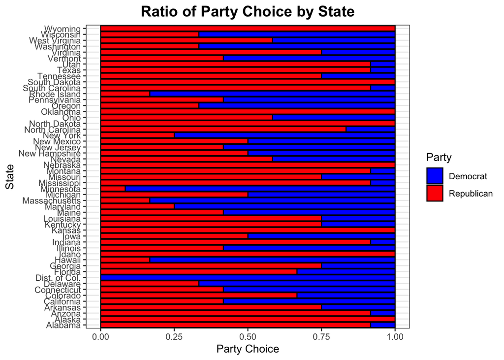

```r
state_voting_ratio <- elections %>%
    filter(Winner != "") %>%
    group_by(State, Winner) %>%
    count(State) %>%
    arrange(Winner, -n)



ggplot(state_voting_ratio, aes(State, n, fill = Winner))+
    geom_bar(position = "fill", stat = "identity", color = "black")+
    coord_flip()+
    theme(
    legend.position = "right",
    )+
    scale_fill_manual(values = c("blue", "red"))+
    theme_bw() +
    labs(x="State", y="Party Choice", title="Ratio of Party Choice by State", fill = "Party") +
    theme(
        plot.title = element_text(hjust = 0.5, face = "bold", size = 15),
        axis.title = element_text(size = 11),
        )
```

## Approval Ratings

### Initial

Here we are given the initial approval ratings of the current president. For every term the approval rating is higher than the disapproval, except for the 2016-2020 term. We also see that within our data, most approval ratings start off at about 60%.

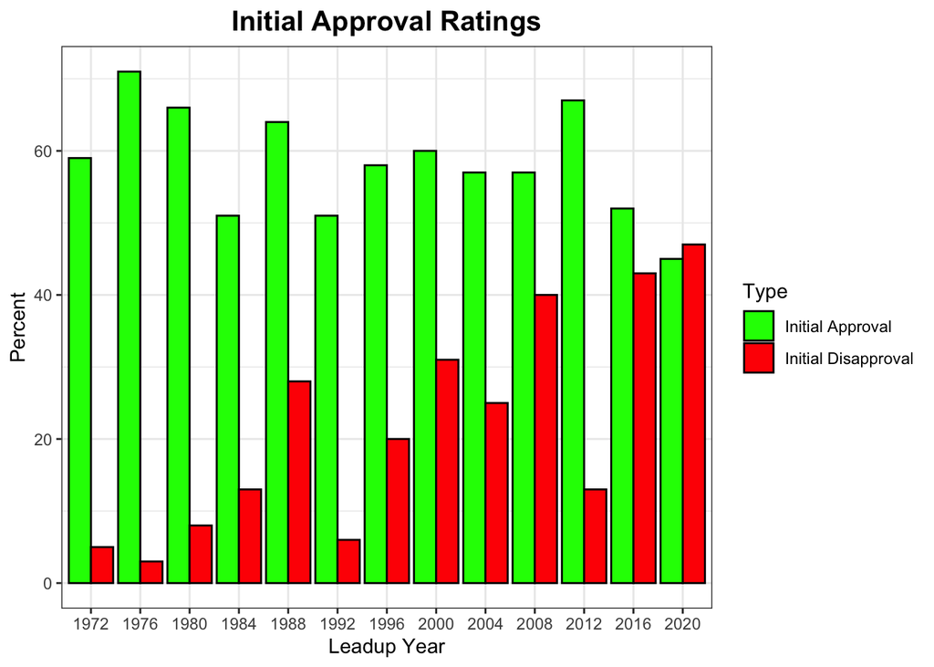

```r
inital_approval_rates <- elections %>%
    filter(State == "Alabama") %>%
    pivot_longer(cols=c("President_Initial_Approval", "President_Initial_Disapproval"), names_to='Type', values_to="value") %>%
    ggplot(aes(x=Year, y=value, fill=Type)) +
    geom_bar(stat='identity', position='dodge', color = "black") +
    scale_fill_manual(labels = c("Initial Approval", "Initial Disapproval"), values = c("green", "red"))+
    theme_bw() +
    labs(x="Leadup Year", y="Percent", title="Initial Approval Ratings", fill = "Type") +
    theme(
        plot.title = element_text(hjust = 0.5, face = "bold", size = 15),
        axis.title = element_text(size = 11),
        )


inital_approval_rates
```

### Midterm

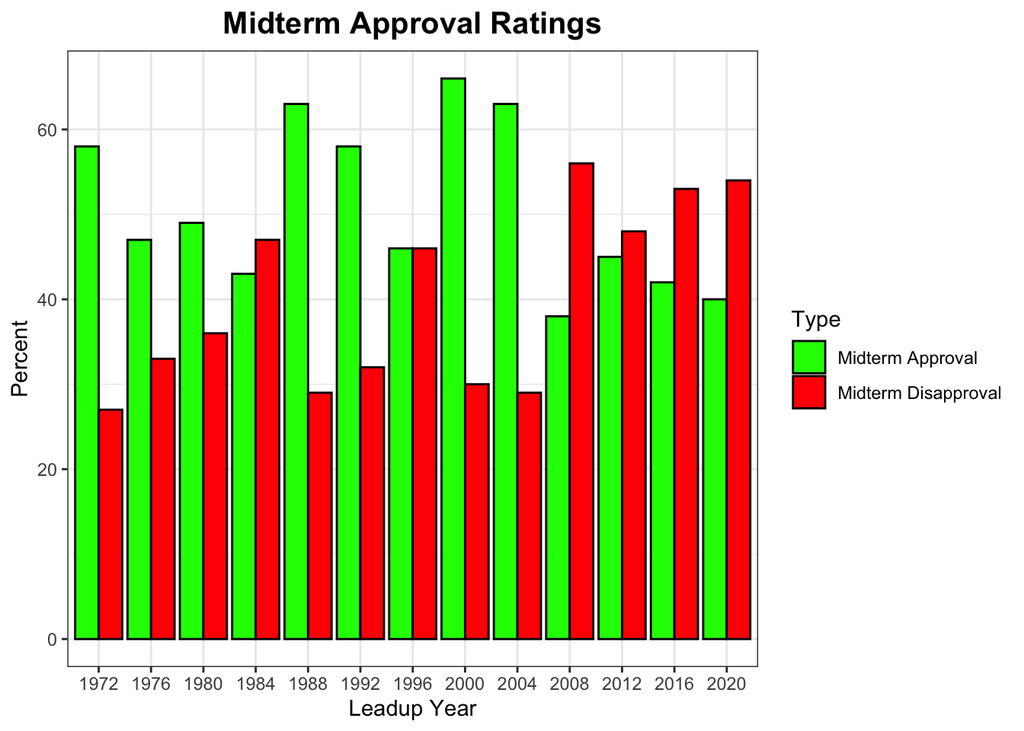

```r
mid_approval_rates <- elections %>%
    filter(State == "Alabama") %>%
    pivot_longer(cols=c("President_Mid_Approval", "President_Mid_Disapproval"), names_to='variable', values_to="value") %>%
    ggplot(aes(x=Year, y=value, fill=variable)) +
    geom_bar(stat='identity', position='dodge', color = "black")+
    scale_fill_manual(labels = c("Midterm Approval", "Midterm Disapproval"), values = c("green", "red"))+
    theme_bw() +
    labs(x="Leadup Year", y="Percent", title="Midterm Approval Ratings", fill = "Type") +
    theme(
        plot.title = element_text(hjust = 0.5, face = "bold", size = 15),
        axis.title = element_text(size = 11),
        )


mid_approval_rates
```

### Final

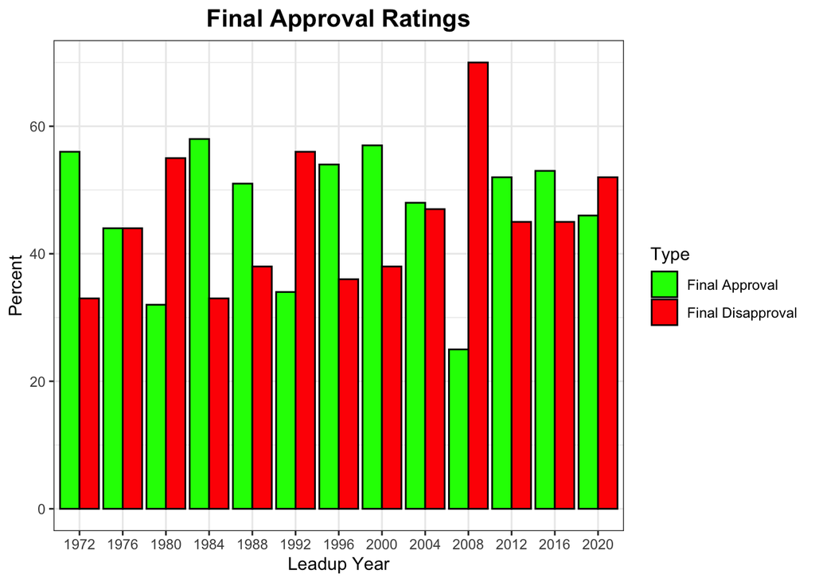

```r
final_approval_rates <- elections %>%
    filter(State == "Alabama") %>%
    pivot_longer(cols=c("President_Last_Approval", "President_Last_Disapproval"), names_to='variable', values_to="value") %>%
    ggplot(aes(x=Year, y=value, fill=variable)) +
    geom_bar(stat='identity', position='dodge', color = "black")+
    scale_fill_manual(labels = c("Final Approval", "Final Disapproval"), values = c("green", "red"))+
    theme_bw() +
    labs(x="Leadup Year", y="Percent", title="Final Approval Ratings", fill = "Type") +
    theme(
        plot.title = element_text(hjust = 0.5, face = "bold", size = 15),
        axis.title = element_text(size = 11),
        )


final_approval_rates
```

# **Logistic Regression Modeling**

Now that we have a grasp of the data set, we’ll begin our logistic regression modeling.

## State by State

To start, we’ll do a prediction model of a single state, which gives us a formula we can use for other states. From the data below we see that adding all these variables doesn’t offer a good prediction. The reason for this, is that our data is too wide for how many entries we have. For a quality multivariate logistic regression, we would want more like 30 different elections, but we only have the 12, hence why none of the variables are statistically relevant. Instead we can try and do one of the entire country since it offers more than 12 rows.

```r
Alabama <- elections %>%
    filter(State == "Alabama")


predict_Alabama <- glm(as.factor(Winner) ~ Current_President_Party + President_Initial_Approval + President_Initial_Disapproval + President_Mid_Approval + President_Mid_Disapproval + President_News_Conference + President_Ex_Orders + President_Last_Approval + President_Last_Disapproval + President_Party_Mid_Change_House + President_Party_Mid_Change_Senate, Alabama, family = "binomial")
summary(predict_Alabama)
```

```
##
## Call:
## glm(formula = as.factor(Winner) ~ Current_President_Party + President_Initial_Approval +
##     President_Initial_Disapproval + President_Mid_Approval +
##     President_Mid_Disapproval + President_News_Conference + President_Ex_Orders +
##     President_Last_Approval + President_Last_Disapproval + President_Party_Mid_Change_House +
##     President_Party_Mid_Change_Senate, family = "binomial", data = Alabama)
##
## Deviance Residuals:
##  [1]  0  0  0  0  0  0  0  0  0  0  0  0
##
## Coefficients:
##                                     Estimate Std. Error z value Pr(>|z|)
## (Intercept)                        3.946e+02  3.804e+06       0        1
## Current_President_PartyRepublican -4.992e+01  2.586e+05       0        1
## President_Initial_Approval        -5.490e+00  3.240e+04       0        1
## President_Initial_Disapproval     -2.756e+00  1.931e+04       0        1
## President_Mid_Approval             2.337e+00  3.216e+04       0        1
## President_Mid_Disapproval          3.627e-01  5.200e+04       0        1
## President_News_Conference         -1.766e+00  9.341e+03       0        1
## President_Ex_Orders               -1.328e-01  1.571e+03       0        1
## President_Last_Approval           -2.022e+00  3.069e+04       0        1
## President_Last_Disapproval         1.285e+00  3.645e+04       0        1
## President_Party_Mid_Change_House  -7.164e-02  8.918e+03       0        1
## President_Party_Mid_Change_Senate -4.684e+00  3.675e+04       0        1
##
## (Dispersion parameter for binomial family taken to be 1)
##
##     Null deviance: 6.8841e+00  on 11  degrees of freedom
## Residual deviance: 5.1440e-10  on  0  degrees of freedom
##   (1 observation deleted due to missingness)
## AIC: 24
##
## Number of Fisher Scoring iterations: 23
```

## Countrywide

With the data we have below we realize another crucial feature of our data. This data was originally created with the purpose of doing several smaller logistic regressions of the states and then adding them with their respective electoral votes to get an overall national winner. That however is not possible as prove by the previous state by state attempt. Because of this fact, the data only has 12 unique rows, one for every election year, and so the data is the exact same as the state by state comparison. In order to fix this, we would need to collect more election data for many years prior. There is, however, a way we can use this data and find the statistical relevance of a single variable.

```r
elections_ <- elections %>%
    filter(Year != "2020") %>%
    filter(State == "Alabama")

keep <- function (x) {
    if (is.factor(x) || is.character(x)) {
        length(unique(x[!is.na(x)])) > 1
    } else TRUE
}

elections_keep <- elections_[sapply(elections_, keep)]

predict_Alabama <- glm(as.factor(National_Winner) ~ . -Winner -Year -Total_Electors, elections_keep, family = "binomial")
summary(predict_Alabama)
```

```
##
## Call:
## glm(formula = as.factor(National_Winner) ~ . - Winner - Year -
##     Total_Electors, family = "binomial", data = elections_keep)
##
## Deviance Residuals:
##  [1]  0  0  0  0  0  0  0  0  0  0  0  0
##
## Coefficients: (5 not defined because of singularities)
##                                     Estimate Std. Error z value Pr(>|z|)
## (Intercept)                        4.815e+02  3.804e+06       0        1
## Current_President_PartyRepublican -6.111e+01  2.586e+05       0        1
## President_Initial_Approval        -5.027e+00  3.240e+04       0        1
## President_Initial_Disapproval     -3.893e+00  1.931e+04       0        1
## President_Mid_Approval             3.162e-02  3.216e+04       0        1
## President_Mid_Disapproval         -2.348e-01  5.200e+04       0        1
## President_Last_Approval           -8.423e-01  3.069e+04       0        1
## President_Last_Disapproval         1.899e+00  3.645e+04       0        1
## President_Party_Mid_Change_House   1.565e+00  8.918e+03       0        1
## President_Party_Mid_Change_Senate -6.480e+00  3.675e+04       0        1
## President_News_Conference         -2.385e+00  9.341e+03       0        1
## President_Ex_Orders               -1.142e-01  1.571e+03       0        1
## Previous_Popular_Margin                   NA         NA      NA       NA
## Previous_Electoral_Margin                 NA         NA      NA       NA
## Previous_Voter_Turnout                    NA         NA      NA       NA
## Change_In_PowerYes                        NA         NA      NA       NA
## Impeachment_PresenceYes                   NA         NA      NA       NA
##
## (Dispersion parameter for binomial family taken to be 1)
##
##     Null deviance: 1.6301e+01  on 11  degrees of freedom
## Residual deviance: 5.1440e-10  on  0  degrees of freedom
## AIC: 24
##
## Number of Fisher Scoring iterations: 23
```

# **Logistic Regression Modeling: Revised**

Here we can load in a new data set that ignores the state variable and instead gives priority to the year. While we many not be able to do a multivariate logistic regression, we can look into individual variables and determine if there exists and correlation to predicting the election. I have listed the top three variables when it comes to predicting the U.S. election.

```r
elections_total <- read.csv("/Users/z_jordan/Desktop/Last Chance.csv", na.strings=c(""))

elections_total$Year <- factor(elections_total$Year)
elections_total$Previous_Voter_Turnout <- parse_number(as.character(elections_total$Previous_Voter_Turnout))
elections_total$Current_President_Party <- factor(elections_total$Current_President_Party)
elections_total$Change_In_Power <- factor(elections_total$Change_In_Power)
elections_total$Impeachment_Presence <- factor(elections_total$Impeachment_Presence)
elections_total$National_Winner <- factor(elections_total$National_Winner)
```

## Top Three Predictor Varibles

### One

For the first variable we are attempting to predict the president elect’s party based solely upon the number of seats the president’s party lost or gained during the midterm. We create the model and then at the bottom we calculate the R-squared value and the a p-value for it. Surprisingly, this piece of data has a potentially large correlation (R-squared of 0.428) with the party determination, and it is statistically significant (p-value of 0.00826). With more data we might be able to add another variable to strengthen this model.

```r
predict_election <- glm(as.factor(National_Winner) ~ President_Party_Mid_Change_House, elections_total, family = "binomial")
summary(predict_election)
```

```
##
## Call:
## glm(formula = as.factor(National_Winner) ~ President_Party_Mid_Change_House,
##     family = "binomial", data = elections_total)
##
## Deviance Residuals:
##     Min       1Q   Median       3Q      Max
## -1.9831  -0.3631   0.2278   0.7011   1.3775
##
## Coefficients:
##                                  Estimate Std. Error z value Pr(>|z|)
## (Intercept)                       2.82635    1.66122   1.701   0.0889 .
## President_Party_Mid_Change_House  0.12636    0.07629   1.656   0.0977 .
## ---
## Signif. codes:  0 '***' 0.001 '**' 0.01 '*' 0.05 '.' 0.1 ' ' 1
##
## (Dispersion parameter for binomial family taken to be 1)
##
##     Null deviance: 16.3006  on 11  degrees of freedom
## Residual deviance:  9.3255  on 10  degrees of freedom
##   (1 observation deleted due to missingness)
## AIC: 13.325
##
## Number of Fisher Scoring iterations: 6
```

```r
ll.null <- predict_election$null.deviance/-2
ll.proposed <- predict_election$deviance/-2
(ll.null - ll.proposed) / ll.null
```

```
## [1] 0.4279059
```

```r
1 - pchisq(2*(ll.proposed - ll.null), df=(length(predict_election$coefficients)-1))
```

```
## [1] 0.008264977
```

### Two

Now for the second variable we attempt to predict the president elect’s party based upon on the president’s midterm approval rating. After creating the model we find a less statistically significant variable, but if combined with another variable it could produce better results. It is close enough to being statistically relevant that it deserves more exploration.

```r
predict_election <- glm(as.factor(National_Winner) ~ President_Mid_Approval, elections_total, family = "binomial")
summary(predict_election)
```

```
##
## Call:
## glm(formula = as.factor(National_Winner) ~ President_Mid_Approval,
##     family = "binomial", data = elections_total)
##
## Deviance Residuals:
##     Min       1Q   Median       3Q      Max
## -1.6955  -1.0701   0.5313   0.8298   1.4499
##
## Coefficients:
##                        Estimate Std. Error z value Pr(>|z|)
## (Intercept)            -5.31276    3.99642  -1.329    0.184
## President_Mid_Approval  0.11171    0.07962   1.403    0.161
##
## (Dispersion parameter for binomial family taken to be 1)
##
##     Null deviance: 16.301  on 11  degrees of freedom
## Residual deviance: 13.863  on 10  degrees of freedom
##   (1 observation deleted due to missingness)
## AIC: 17.863
##
## Number of Fisher Scoring iterations: 4
```

```r
ll.null <- predict_election$null.deviance/-2
ll.proposed <- predict_election$deviance/-2
(ll.null - ll.proposed) / ll.null
```

```
## [1] 0.1495301
```

```r
1 - pchisq(2*(ll.proposed - ll.null), df=(length(predict_election$coefficients)-1))
```

```
## [1] 0.1184697
```

### Three

Now for the third variable we use the number of news conferences each president did to predict the next party. This produces a better result than the previous variable and adds to the need to explore more, once additional data has been collected.

```r
predict_election <- glm(as.factor(National_Winner) ~ President_News_Conference, elections_total, family = "binomial")
summary(predict_election)
```

```
##
## Call:
## glm(formula = as.factor(National_Winner) ~ President_News_Conference,
##     family = "binomial", data = elections_total)
##
## Deviance Residuals:
##     Min       1Q   Median       3Q      Max
## -1.3374  -1.0085   0.4031   0.6384   1.8501
##
## Coefficients:
##                           Estimate Std. Error z value Pr(>|z|)
## (Intercept)                3.14514    1.97532   1.592    0.111
## President_News_Conference -0.08957    0.05975  -1.499    0.134
##
## (Dispersion parameter for binomial family taken to be 1)
##
##     Null deviance: 16.301  on 11  degrees of freedom
## Residual deviance: 11.724  on 10  degrees of freedom
##   (1 observation deleted due to missingness)
## AIC: 15.724
##
## Number of Fisher Scoring iterations: 5
```

```r
ll.null <- predict_election$null.deviance/-2
ll.proposed <- predict_election$deviance/-2
(ll.null - ll.proposed) / ll.null
```

```
## [1] 0.2807708
```

```r
1 - pchisq(2*(ll.proposed - ll.null), df=(length(predict_election$coefficients)-1))
```

```
## [1] 0.03240874
```

# **Logistic Regression Modeling: Ablation**

For our final portion of modeling, we attempt to answer what if questions about the data. For this I chose to explore the 2016 election results. They were very close in terms of the popular vote and the elector vote didn’t match the popular vote. Clearly, it was a close electoral race, and for that reason we will load in the last data set, with the only difference being the 2016 party that won. All the other data will stay the same, but the party that won and the current president’s political affiliation will be changed from ‘Republican’ to ‘Democrat’

```r
elections_total_ablation <- read.csv("/Users/z_jordan/Desktop/What_IF.csv", na.strings=c(""))

elections_total_ablation$Year <- factor(elections_total_ablation$Year)
elections_total_ablation$Previous_Voter_Turnout <- parse_number(as.character(elections_total_ablation$Previous_Voter_Turnout))
elections_total_ablation$Current_President_Party <- factor(elections_total_ablation$Current_President_Party)
elections_total_ablation$Change_In_Power <- factor(elections_total_ablation$Change_In_Power)
elections_total_ablation$Impeachment_Presence <- factor(elections_total_ablation$Impeachment_Presence)
elections_total_ablation$National_Winner <- factor(elections_total_ablation$National_Winner)
```

## Ablation of Predictor Varibles

For this, we’ll explore the exact same variables as before as look at the differences in the results.

### One

We see that with the Democratic win, the correlation drops a bit, but it still remains statistically important. The relatively close R-squared could be due to the fact that it was a close election and the fact that it is lesser could mean that the model predicted ‘Republican’ for this model. Either way it is an interesting statistic and should be explored further.

```r
predict_election_ablation <- glm(as.factor(National_Winner) ~ President_Party_Mid_Change_House, elections_total_ablation, family = "binomial")
summary(predict_election_ablation)
```

```
##
## Call:
## glm(formula = as.factor(National_Winner) ~ President_Party_Mid_Change_House,
##     family = "binomial", data = elections_total_ablation)
##
## Deviance Residuals:
##     Min       1Q   Median       3Q      Max
## -1.6263  -0.7103   0.1159   0.7489   1.5672
##
## Coefficients:
##                                  Estimate Std. Error z value Pr(>|z|)
## (Intercept)                        1.8543     1.2658   1.465    0.143
## President_Party_Mid_Change_House   0.1052     0.0647   1.626    0.104
##
## (Dispersion parameter for binomial family taken to be 1)
##
##     Null deviance: 16.636  on 11  degrees of freedom
## Residual deviance: 10.950  on 10  degrees of freedom
##   (1 observation deleted due to missingness)
## AIC: 14.95
##
## Number of Fisher Scoring iterations: 5
```

```r
ll.null <- predict_election_ablation$null.deviance/-2
ll.proposed <- predict_election_ablation$deviance/-2
(ll.null - ll.proposed) / ll.null
```

```
## [1] 0.3417964
```

```r
1 - pchisq(2*(ll.proposed - ll.null), df=(length(predict_election_ablation$coefficients)-1))
```

```
## [1] 0.01710113
```

### Two

This variable actually became more statistically relevant, which could mean the model predicted ‘Democrat’ for the 2016 election. It may not be the best variable to use alone when predicting elections however, because it better explains a ‘Democrat’ win in 2016 rather than the actual ‘Republican’ victory.

```r
predict_election_ablation <- glm(as.factor(National_Winner) ~ President_Mid_Approval, elections_total_ablation, family = "binomial")
summary(predict_election_ablation)
```

```
##
## Call:
## glm(formula = as.factor(National_Winner) ~ President_Mid_Approval,
##     family = "binomial", data = elections_total_ablation)
##
## Deviance Residuals:
##      Min        1Q    Median        3Q       Max
## -1.69583  -0.79615  -0.03106   0.55989   1.78567
##
## Coefficients:
##                        Estimate Std. Error z value Pr(>|z|)
## (Intercept)            -8.63214    4.72275  -1.828   0.0676 .
## President_Mid_Approval  0.16895    0.09273   1.822   0.0684 .
## ---
## Signif. codes:  0 '***' 0.001 '**' 0.01 '*' 0.05 '.' 0.1 ' ' 1
##
## (Dispersion parameter for binomial family taken to be 1)
##
##     Null deviance: 16.636  on 11  degrees of freedom
## Residual deviance: 11.761  on 10  degrees of freedom
##   (1 observation deleted due to missingness)
## AIC: 15.761
##
## Number of Fisher Scoring iterations: 4
```

```r
ll.null <- predict_election_ablation$null.deviance/-2
ll.proposed <- predict_election_ablation$deviance/-2
(ll.null - ll.proposed) / ll.null
```

```
## [1] 0.2930385
```

```r
1 - pchisq(2*(ll.proposed - ll.null), df=(length(predict_election_ablation$coefficients)-1))
```

```
## [1] 0.02725078
```

### Three

Lastly, we find that this variable didn’t change all that much, which could possibly mean that the election was very close and sat on the cusp of the logistic regression curve.

```r
predict_election_ablation <- glm(as.factor(National_Winner) ~ President_News_Conference, elections_total_ablation, family = "binomial")
summary(predict_election_ablation)
```

```
##
## Call:
## glm(formula = as.factor(National_Winner) ~ President_News_Conference,
##     family = "binomial", data = elections_total_ablation)
##
## Deviance Residuals:
##     Min       1Q   Median       3Q      Max
## -1.1052  -0.9166   0.1702   0.6503   2.2326
##
## Coefficients:
##                           Estimate Std. Error z value Pr(>|z|)
## (Intercept)                3.12481    1.99801   1.564    0.118
## President_News_Conference -0.10636    0.06521  -1.631    0.103
##
## (Dispersion parameter for binomial family taken to be 1)
##
##     Null deviance: 16.636  on 11  degrees of freedom
## Residual deviance: 11.351  on 10  degrees of freedom
##   (1 observation deleted due to missingness)
## AIC: 15.351
##
## Number of Fisher Scoring iterations: 5
```

```r
ll.null <- predict_election_ablation$null.deviance/-2
ll.proposed <- predict_election_ablation$deviance/-2
(ll.null - ll.proposed) / ll.null
```

```
## [1] 0.3176752
```

```r
1 - pchisq(2*(ll.proposed - ll.null), df=(length(predict_election_ablation$coefficients)-1))
```

```
## [1] 0.02151365
```

## Potential Changes

There are a couple of changes I would make to the data set before I continued exploring its prediction capabilities. First, and most important, it needs more data points to actual be useful as a predictor. While it shows potential, a coin flip would be just as accurate as the models created. Second, I would gather more data from the year, just to see if there was an odd variable that better predicted elections, such as stock market trading.

# **Conclusion**

Overall, the results found were inconclusive because while it didn’t predict the elections very well, it showed possibility in some of the variables. If more data was collected and added to the set we might be able to find conclusive results, but as of right now there exists a reasonable suspicion that these variables could predict which party will win the election. This concludes my analysis and I leave any results up to interpretation.

# **Resources**

**Data compiled from the following sources:**

[1] Gerhard Peters. “Presidential Election Margins of Victory.” The American Presidency Project. Ed. John T. Woolley and Gerhard Peters. Santa Barbara, CA: University of California. 1999-2021. https://www.presidency.ucsb.edu/node/323891 Accessed 11 Nov. 2020.

[2] Gerhard Peters and John T. Woolley, “Executive Orders.” The American Presidency Project. Ed. John T. Woolley and Gerhard Peters. Santa Barbara, CA. 1999-2021. https://www.presidency.ucsb.edu/node/323876 Accessed 12 Nov. 2020.

[3] Gerhard Peters. “Presidential News Conferences.” The American Presidency Project. Ed. John T. Woolley and Gerhard Peters. Santa Barbara, CA: University of California. https://www.presidency.ucsb.edu/node/323900 Accessed 12 Nov. 2020.

[4] The American Presidency Project. “Seats in Congress Gained/Lost by the President’s Party in Mid-Term Elections.” Santa Barbara, CA: University of California. https://www.presidency.ucsb.edu/node/332343/. Accessed 11 Nov. 2020.

[5] The American Presidency Project. “Election Statistics” Santa Barbara, CA: University of California. https://www.presidency.ucsb.edu/statistics/elections. Accessed 10 Nov. 2020.

[6] The American Presidency Project. “Voter Turnout in Presidential Elections.” Santa Barbara, CA: University of California. https://www.presidency.ucsb.edu/statistics/data/voter-turnout-in-presidential-elections. Accessed 13 Nov. 2020.

[7] The American Presidency Project. “Presidential Job Approval.” Santa Barbara, CA: University of California. https://www.presidency.ucsb.edu/statistics/data/presidential-job-approval. Accessed 13 Nov. 2020.